# Jerv

## Analyser av jervbestand

Her henter jeg data om jervbestandend i Nogre fra Naturindeksdatabsen. Tidsserien er ikke komplett og det mangler bl.a. data fra 2020 som kanskje er tilgjengelig i rovbase. Men vi det har ikke skjedd noe dramatisk med polpulasjonen siden siset NI-vurdering.

# Import - Importerer data fra NI

Fyll inn ditt eget passord og brukernavn

```r
myUser <- "anders.kolstad@nina.no"
myPwd  <- "" # hemmelig passord
```

Importerer data fra NI-databasen og lagrer datasettet på server

```r
jerv <- NIcalc::importDatasetApi(
  username = myUser,
  password = myPwd,
  eco = "Fjell",
  indic = "Jerv",
  year = c(1990,2000,2010,2014,2019))
saveRDS(jerv, "../data/jervNIexport.rds")
```

```r
jerv <- readRDS("../data/jervNIexport.rds")
```

# Assemble - Strukturerer datasettet

```r
myNIunits <- c(allArea = T, parts = T, counties = F)
```

Inkludrer alle BSunits (kommuner):

```r
myPartOfTotal <- 0
```

Siden denne opperasjonen tar litt tid så lagrer jeg outputen på server og henter det tilbake etterpå, så slipper jeg å kjøre gjennom hver gang.

```r
jerv_assemeble <- NIcalc::assembleNiObject(
  inputData = jerv,
  predefNIunits = myNIunits,
  partOfTotal = myPartOfTotal,
  indexType = "thematic",
  part = "ecosystem",
  total = "terrestrial")
saveRDS(jerv_assemeble, "../data/jerv_assemble.rds")
```

```r
jerv_assemeble <- readRDS("../data/jerv_assemble.rds")
```

Indikatorveriene kommer både som tall og i form av sannsynlighetsfunskjoner. Her simulerer jeg indikatorverdier 1000 ganger per år.

```r
# bruker tradOb siden custumDist er NA. Dette er ikke en generisk løsning. Se da heller 'fjellrev'.
obstype <- rep("tradObs", nrow(jerv_assemeble$indicatorValues$'2019'))

myYears <- as.character(c(1990,2000,2010,2014,2019))
for(i in 1:length(myYears)){
# print(i)

myMat <- NIcalc::sampleObsMat(
  ICunitId           = jerv_assemeble$indicatorValues[[i]]$ICunitId,
  value              = jerv_assemeble$indicatorValues[[i]]$expectedValue,
  distrib            = jerv_assemeble$indicatorValues[[i]]$distributionFamilyName,
  mu                 = jerv_assemeble$indicatorValues[[i]]$distParameter1,
  sig                = jerv_assemeble$indicatorValues[[i]]$distParameter2,
  customDistribution = jerv_assemeble$indicatorValues[[i]]$customDistribution,
          obsType = obstype,
          nsim = 1000

)
assign(paste0("myMat", myYears[i]), myMat)
}
```

Her er anslått antall jerv i 2019:

```r
median(colSums(myMat2019))
```

```
## [1] 373.4076
```

Dette ligner å de tallene som allerede finnes i tabellen:

```r
sum(jerv_assemeble$indicatorValues$'2019'$expectedValue)
```

```
## [1] 374.7
```

men nå har vi også fordelingen, dvs usikkerheten:

```r
quantile(colSums(myMat2019), c(0.025, .5, .975))
```

```
##     2.5%      50%    97.5%
## 352.2472 373.4076 397.8049
```

## Fordeling av refverdier

I dette tilfelle har referanseverdiene også en usikkerhet. Vi kan regnet ut fordelingen på samme måte som over - ta colsums - og dele mu med ref for å få fordelingen av de skalerte indikatorverdiene. Husk å trunkere alle verdier over 1. Refverdiene er like for alle år.

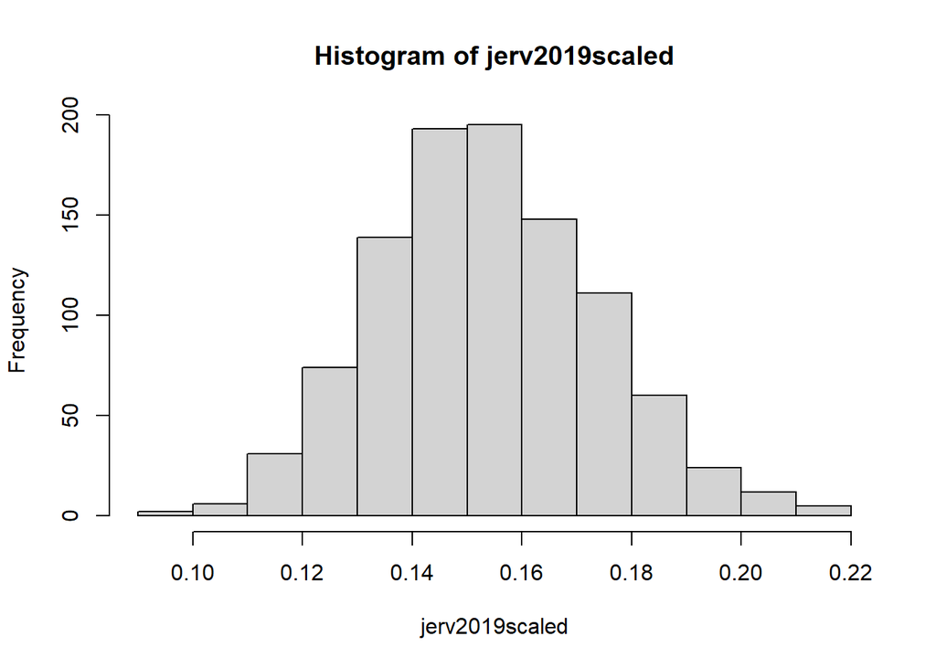

```r
myMatr <- NIcalc::sampleObsMat(
            jerv_assemeble$referenceValues$ICunitId,
            jerv_assemeble$referenceValues$expectedValue,
            jerv_assemeble$referenceValues$distributionFamilyName,
            mu = jerv_assemeble$referenceValues$distParameter1,
            sig = jerv_assemeble$referenceValues$distParameter2,
            customDistribution = jerv_assemeble$referenceValues$customDistribution,
            obsType = obstype,
            nsim =1000
        )

jerv2019scaled <- colSums(myMat2019)/colSums(myMatr)
hist(jerv2019scaled)
```

Her er det ingen grunn til å trunkere verdier over 1.

Jeg gjør det først slik at den nasjoneale verdien er summen av tilstandsverdeien og referanseverdiene i regionene. Deretter gjør jeg det på den andre måten, den den nasjonale verdiener gjennomsnittet av de skalerte regionale verdiene. Deretter sammenligner jeg de to svarene.

## Skalering

Her slår jeg sammen de relevante rovviltregionene til ØT regioner. Jeg inkluderer alle rovviltregioner som overlapper med den respektive ØTregionen. Her er det et forbedringspotensial ved å veie dataene fra de ulike rovviltregionene ulikt ettersom hvro stor overlapp de har med ØT-regionene.

```r
table(jerv_assemeble$referenceValues$ICunitName,
      jerv_assemeble$referenceValues$ICunitId)
```

```
##
##                   1302 1304 1305 1311 1313 1315 1316 5141
##   Rovviltregion 1    0    0    0    1    0    0    0    0
##   Rovviltregion 2    0    0    0    0    1    0    0    0
##   Rovviltregion 3    0    0    0    0    0    1    0    0
##   Rovviltregion 4    0    0    0    0    0    0    0    1
##   Rovviltregion 5    0    0    0    0    0    0    1    0
##   Rovviltregion 6    0    0    1    0    0    0    0    0
##   Rovviltregion 7    0    1    0    0    0    0    0    0
##   Rovviltregion 8    1    0    0    0    0    0    0    0
```

```r
nord <- c(1302, 1304)
midt <- 1305
vest <- 1311
sør <- c(1311,1313)
øst <- c(1313, 1315, 5141, 1316)
```

```r
regions <- c("Norge", "N", "C", "W", "S", "E")

# Datasett i kortformat (uten bootstrapping) der de nasjonale verdien er produsert ved å dele de summerte indikatorverdiene på de summerte referanseverdiene
jervTbl <- data.frame(
  reg = rep(regions, each=length(myYears)),
  year = rep(myYears, length(regions)),
  low = NA,
  med = NA,
  upp = NA
)

# Datasett med bootstrappede verdir for regioner
regions2 <- c("N", "C", "W", "S", "E")
jervTbl2 <- data.frame(
  reg = rep(regions2, each=length(myYears)*1000),
  year = rep(myYears, each = 1000, times=length(regions2)),
  val = NA
)

# Datasett (kortformat, uten bootstrapping) av uskallerte verdier
# Brukes kun til plotting
jervTbl_unscaled <- data.frame(
  reg = rep(regions, each=length(myYears)),
  year = rep(myYears, length(regions)),
  low = NA,
  med = NA,
  upp = NA
)

for(i in regions){

   for(n in myYears){

     tempMat <- get(paste0("myMat", n))
     tempMat <- as.data.frame(tempMat)
     myMatrX <- as.data.frame(myMatr)

     if(i == "N") tempMat <- tempMat[row.names(tempMat) %in% nord,]
     if(i == "C") tempMat <- tempMat[row.names(tempMat) %in% midt,]
     if(i == "W") tempMat <- tempMat[row.names(tempMat) %in% vest,]
     if(i == "S") tempMat <- tempMat[row.names(tempMat) %in% sør,]
     if(i == "E") tempMat <- tempMat[row.names(tempMat) %in% øst,]

     if(i == "N") myMatrX <- myMatrX[row.names(myMatrX) %in% nord,]
     if(i == "C") myMatrX <- myMatrX[row.names(myMatrX) %in% midt,]
     if(i == "W") myMatrX <- myMatrX[row.names(myMatrX) %in% vest,]
     if(i == "S") myMatrX <- myMatrX[row.names(myMatrX) %in% sør,]
     if(i == "E") myMatrX <- myMatrX[row.names(myMatrX) %in% øst,]


     tempMatScaled <- colSums(tempMat)/colSums(myMatrX)

     # add 1000 observations to the dataframe
     if(i != "Norge") {
     jervTbl2[jervTbl2$reg==i & jervTbl2$year==n, "val"] <- tempMatScaled
     }

     jervTbl[jervTbl$reg==i & jervTbl$year==n, 3:5] <- quantile(tempMatScaled, c(0.025, .5, .975))
     jervTbl_unscaled[jervTbl_unscaled$reg==i & jervTbl$year==n, 3:5] <-
       quantile(colSums(tempMat), c(0.025, .5, .975))


 }

}
```

I jervTbl er de nasjonale verdiene regnet ut ved å summere indikatorverdiene og referanseverdiene for hele landet. Dette datasettet er ikke bootstrappet. I jervTbl2 (bootstrappet data) er det ikke none nasjonele verdier enda. Nå skal jeg lage de ved å bootstrappe de regionale verdiene og veie etter total fjellareal.

# Veiing

Regner ut nasjonale indikatorverdier som et veid (etter total fjelareal) gjennomsnitt av vedien i regionene. Veiingen gjøres ved å samle større antall verdier for de regionene som har mest fjell i seg.

```r
wgt <- readRDS("../data/fjellareal.rds")
wgt$Fjellareal2 <- wgt$Fjellareal/max(wgt$Fjellareal)
wgt$reg <- c("N", "C", "E", "W", "S")
```

```r
regions <- c("N", "C", "W", "S", "E")

jervNorge <- data.frame(
  reg = rep("Norge", 5000),
  year = rep(myYears, each = 200, times=length(regions)),
  val = NA
)

for(n in myYears){
    temp <- jervTbl2[jervTbl2$year == n,]

    temp2 <- c(
      sample(temp$val[temp$reg == "N"], wgt$Fjellareal2[wgt$reg == "N"]*1000, replace =T),
      sample(temp$val[temp$reg == "E"], wgt$Fjellareal2[wgt$reg == "E"]*1000, replace =T),
      sample(temp$val[temp$reg == "W"], wgt$Fjellareal2[wgt$reg == "W"]*1000, replace =T),
      sample(temp$val[temp$reg == "S"], wgt$Fjellareal2[wgt$reg == "S"]*1000, replace =T),
      sample(temp$val[temp$reg == "C"], wgt$Fjellareal2[wgt$reg == "C"]*1000, replace =T)
    )

    jervNorge$val[jervNorge$year == n] <- sample(temp2, 1000)
}
```

Bind together

```r
jervTbl2 <- rbind(jervTbl2, jervNorge)
```

# Plotting

```r
#source("indicator_plots2.R")
eval(parse("indicator_plots.R", encoding="UTF-8"))
eval(parse("indicator_plots2.R", encoding="UTF-8"))
```

Sammenligner de to metodene for å regne ut nasjonale verdier.

```r
sumMethod <- jervTbl[jervTbl$reg=="Norge",c("year", "med")]
sumMethod$method <- "sum method"
sumMethod
```

```
##   year       med     method
## 1 1990 0.1030795 sum method
## 2 2000 0.1217768 sum method
## 3 2010 0.1848988 sum method
## 4 2014 0.1610586 sum method
## 5 2019 0.1523820 sum method
```

```r
meanMethod <- aggregate(data=jervTbl2[jervTbl2$reg=="Norge",],
          val~year,
          FUN= mean)
meanMethod$method <- "mean method"
meanMethod
```

```
##   year       val      method
## 1 1990 0.1085666 mean method
## 2 2000 0.1210525 mean method
## 3 2010 0.1717789 mean method
## 4 2014 0.1516358 mean method
## 5 2019 0.1394812 mean method
```

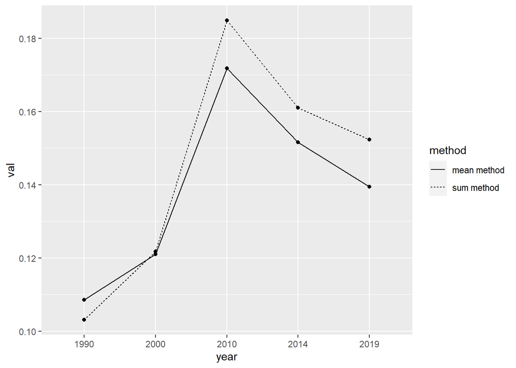

```r
names(sumMethod) <- names(meanMethod)
comp <- rbind(sumMethod, meanMethod)
ggplot(data=comp)+
  geom_line(aes(x=year, y=val, linetype=method, group = method))+
  geom_point(aes(x=year, y=val))
```

Metoden vi bruker (mean metoden) gir litt lavere skår.

# Oppsummering

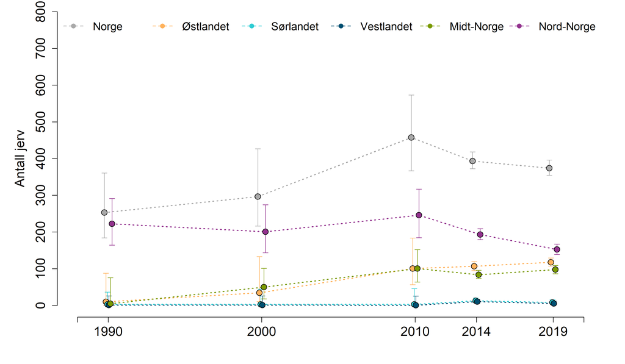

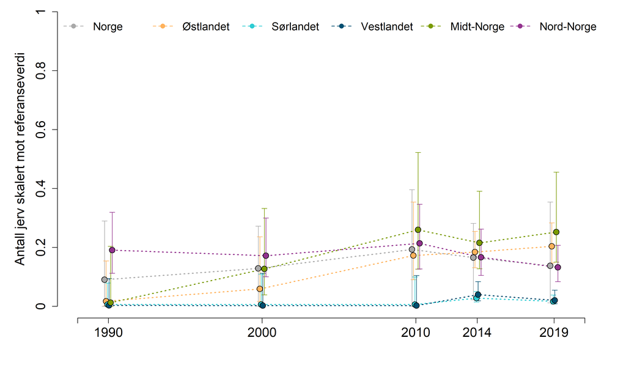

Under er tabellen med skalerte verdier for hvert år og region (med = median, og det er det som er ‘tilstanden’)

```r
finalTbl <- aggregate(data=jervTbl2,
          val~year+reg,
          FUN= function(x) round(
            quantile(x, c(.025, .5, .975)), 2))

finalTbl <- do.call(data.frame, finalTbl)
names(finalTbl) <- c("year", "reg", "low", "med", "upp")

DT::datatable(
  finalTbl,
  extensions = "FixedColumns",
  options = list(
    scrollX = TRUE,
    scrollY=T,
    pageLength = 10
  ))
```

|  | year | reg | low | med | upp |
| --- | --- | --- | --- | --- | --- |
| 1 | 1990 | C | 0 | 0.01 | 0.21 |
| 2 | 2000 | C | 0.04 | 0.13 | 0.31 |
| 3 | 2010 | C | 0.12 | 0.26 | 0.51 |
| 4 | 2014 | C | 0.12 | 0.21 | 0.4 |
| 5 | 2019 | C | 0.14 | 0.25 | 0.46 |
| 6 | 1990 | E | 0 | 0.02 | 0.16 |
| 7 | 2000 | E | 0.02 | 0.06 | 0.24 |
| 8 | 2010 | E | 0.08 | 0.17 | 0.34 |
| 9 | 2014 | E | 0.13 | 0.18 | 0.26 |
| 10 | 2019 | E | 0.15 | 0.2 | 0.28 |

[output cut: 20 more lines]

# Eksporter csv

```r
write.csv(jervTbl2, "../output/indicator_values/jerv.csv", row.names = F)
```